# Seq_analysis

Alice Osmaston

2024-04-25

```r
# Load necessary packages
pacman::p_load(tidyverse, dplyr, knitr, here, ggplot2)

# Import the datasets from pore occupancy plots and pore scan plots
poreoccupancy <- read_csv(here("data", "Pore_activity_%_pores_sequencing.csv"))
porecount <- read_csv(here("data", "porecount2.csv"))
```

# Analysis of run performance over time using the Pore Occupancy plots from MinKnow Software

From the Minknow software, data was collected from the Pore Occupancy graph. Each hour of the sequencing run, the percentage of pores in the “sequencing” state was collected. This was repeated for each of the four flow cells, reflecting each of the four conditions.

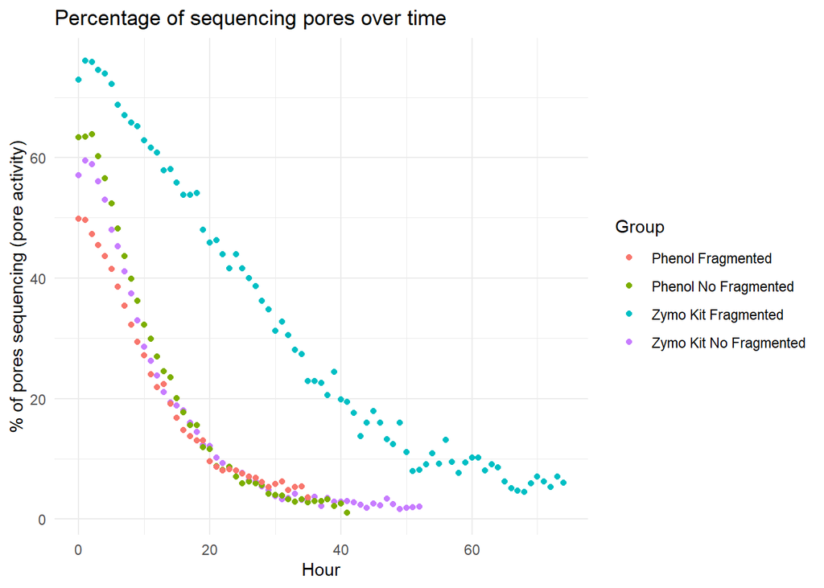

```r
# Plot the raw data
ggplot(data=poreoccupancy, aes(x=Hour, y=`% of pores sequencing (pore activity)`, color=Group))+ geom_point() + labs(title= "Percentage of sequencing pores over time") + theme_minimal()
```

The data was log transformed to linearise it.

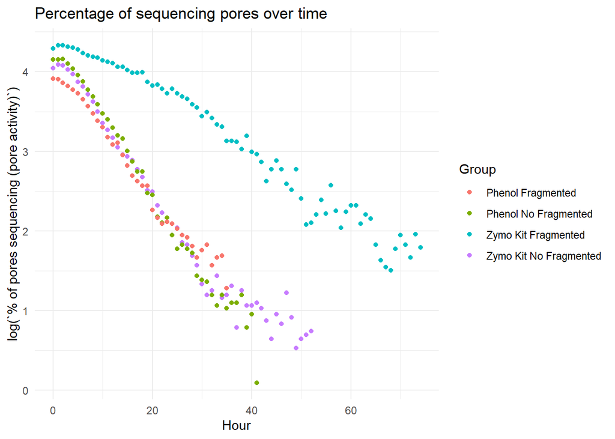

```r
# plot the data using a log transformation on the y axis to make the data linear
ggplot(data=poreoccupancy, aes(x=Hour, y=log(`% of pores sequencing (pore activity)`),color=Group))+ geom_point() + labs(title= "Percentage of sequencing pores over time") + theme_minimal()
```

# Now normalise by the initial percentage of pores sequencing.

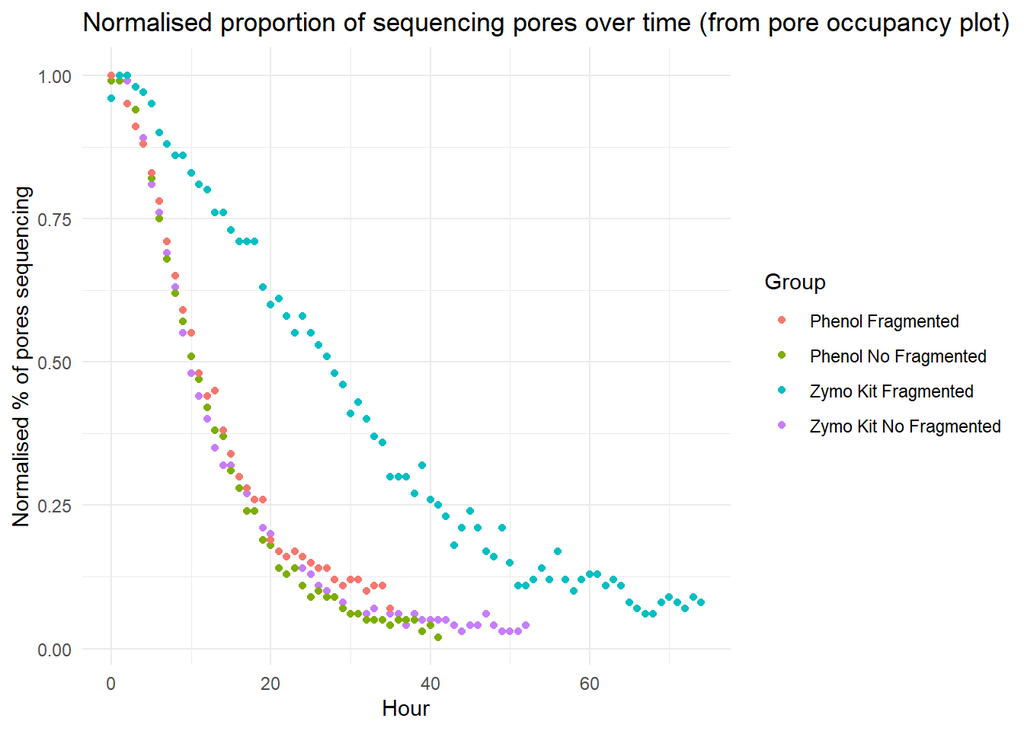

```r
# Plot the raw data
ggplot(data=poreoccupancy, aes(x=Hour, y=`Normalised % of pores sequencing`, color=Group))+ geom_point() + labs(title= "Normalised proportion of sequencing pores over time (from pore occupancy plot)") + theme_minimal()
```

Prepare data to crop the first 2 hours (where percentage of pores sequencing slowly rises) and the final part of the run, where percentage of pores sequencing is variable and non-informative as it tails off towards zero.

```r
# Calculate the maximum hour for each group
max_hours <- poreoccupancy %>%
  group_by(Group) %>%
  summarise(MaxHour = max(Hour))
# Merge the maximum hours with the original data
poreoccupancy <- poreoccupancy %>%
  left_join(max_hours, by = "Group")
```

```r
#crop the first two hours off each condition
front_cropped_occupancy <- poreoccupancy %>%
  subset(Hour >= 3)
```

```r
# simple linear regression model
linear_model_occupancy_front_cropped_normalised <- lm(log(`Normalised % of pores sequencing`) ~ Hour * Group, data = front_cropped_occupancy)

# summarise simple linear regression model
summary(linear_model_occupancy_front_cropped_normalised)
```

```
##
## Call:
## lm(formula = log(`Normalised % of pores sequencing`) ~ Hour *
##     Group, data = front_cropped_occupancy)
##
## Residuals:
##      Min       1Q   Median       3Q      Max
## -0.53984 -0.10310  0.01241  0.09154  0.68169
##
## Coefficients:
##                                   Estimate Std. Error t value Pr(>|t|)
## (Intercept)                       0.119149   0.070631   1.687  0.09330 .
## Hour                             -0.077675   0.003323 -23.372  < 2e-16 ***
## GroupPhenol No Fragmented         0.110840   0.095258   1.164  0.24608
## GroupZymo Kit Fragmented          0.155200   0.083803   1.852  0.06562 .
## GroupZymo Kit No Fragmented      -0.237076   0.089722  -2.642  0.00893 **
## Hour:GroupPhenol No Fragmented   -0.017693   0.004211  -4.201 4.11e-05 ***
## Hour:GroupZymo Kit Fragmented     0.036858   0.003480  10.592  < 2e-16 ***
## Hour:GroupZymo Kit No Fragmented  0.005820   0.003771   1.543  0.12442
## ---
## Signif. codes:  0 '***' 0.001 '**' 0.01 '*' 0.05 '.' 0.1 ' ' 1
##
## Residual standard error: 0.1818 on 186 degrees of freedom
## Multiple R-squared:  0.969,  Adjusted R-squared:  0.9678
## F-statistic: 829.8 on 7 and 186 DF,  p-value: < 2.2e-16
```

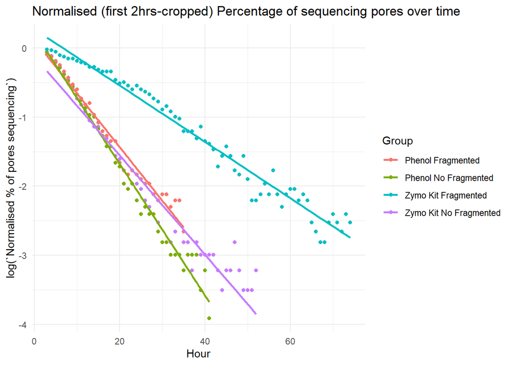

```r
# Plot overlaid linear model
ggplot(data=front_cropped_occupancy, aes(x=Hour, y=log(`Normalised % of pores sequencing`),color=Group))+ geom_point() + labs(title= "Normalised (first 2hrs-cropped) Percentage of sequencing pores over time") + geom_smooth(method = "lm", formula = y ~ x, se = FALSE) + theme_minimal()
```

The variablility at the ends of the sequencing runs affect the slope of the lines and should be cut off so that we compare the linear section of each run.

# Remove final 1/3 of seqeuncing hours from each condition

Now cut off the final third of the sequencing run which is uninformative and highly variable and disperse and keep only the linear region of each plot.

Now cut off the final third of the sequencing run to remove variablitiy and keep only the linear region of each plot.

Hours to cut off from each run:

- **Phenol Fragmented:**  
  `35*0.333` = 11.655
- **Phenol No Fragmented:**  
  `41*0.333` = 13.653
- **Zymo Kit Fragmented:**  
  `74*0.333` = 24.642
- **Zymo Kit No Fragmented:**  
  `52*0.333` = 17.316

```r
# Applying the crop conditions for each group
fully_cropped_occupancy <- front_cropped_occupancy %>%
  filter(
    (Group == "Zymo Kit Fragmented" & Hour <= (MaxHour - 25)) |
    (Group == "Zymo Kit No Fragmented" & Hour <= (MaxHour - 17)) |
    (Group == "Phenol No Fragmented" & Hour <= (MaxHour - 14)) |
    (Group == "Phenol Fragmented" & Hour <= (MaxHour - 12))
  )
```

```r
# simple linear regression model
linear_model_occupancy_fully_cropped_normalised <- lm(log(`Normalised % of pores sequencing`) ~ Hour * Group, data = fully_cropped_occupancy)

# summarise simple linear regression model
summary(linear_model_occupancy_fully_cropped_normalised)
```

```
##
## Call:
## lm(formula = log(`Normalised % of pores sequencing`) ~ Hour *
##     Group, data = fully_cropped_occupancy)
##
## Residuals:
##       Min        1Q    Median        3Q       Max
## -0.285874 -0.043825  0.007776  0.046679  0.234231
##
## Coefficients:
##                                   Estimate Std. Error t value Pr(>|t|)
## (Intercept)                       0.285041   0.044670   6.381 3.59e-09 ***
## Hour                             -0.092123   0.003115 -29.576  < 2e-16 ***
## GroupPhenol No Fragmented         0.061192   0.059894   1.022  0.30903
## GroupZymo Kit Fragmented         -0.041297   0.052329  -0.789  0.43159
## GroupZymo Kit No Fragmented      -0.042281   0.055886  -0.757  0.45082
## Hour:GroupPhenol No Fragmented   -0.011843   0.003931  -3.013  0.00317 **
## Hour:GroupZymo Kit Fragmented     0.053224   0.003251  16.374  < 2e-16 ***
## Hour:GroupZymo Kit No Fragmented -0.001888   0.003493  -0.541  0.58983
## ---
## Signif. codes:  0 '***' 0.001 '**' 0.01 '*' 0.05 '.' 0.1 ' ' 1
##
## Residual standard error: 0.08643 on 118 degrees of freedom
## Multiple R-squared:  0.988,  Adjusted R-squared:  0.9873
## F-statistic:  1392 on 7 and 118 DF,  p-value: < 2.2e-16
```

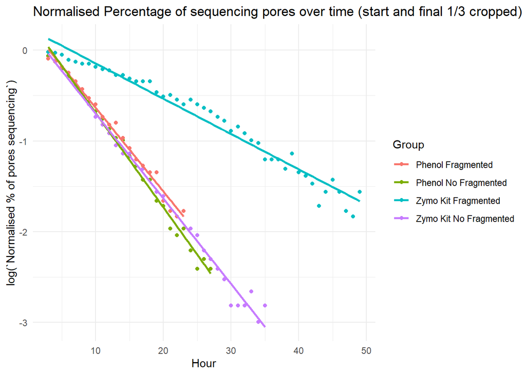

```r
# Plot overlaid linear model
ggplot(data=fully_cropped_occupancy, aes(x=Hour, y=log(`Normalised % of pores sequencing`),color=Group))+ geom_point() + labs(title= "Normalised Percentage of sequencing pores over time (start and final 1/3 cropped)") + geom_smooth(method = "lm", formula = y ~ x, se = FALSE) + theme_minimal()
```

Baseline = -0.092123 which is (log) rate of decline in the reference group (phenol fragmented). Add adjusted rates to the baseline to calculate the slowest rate of decline:

- **Phenol Fragmented:** = `-0.092123`
- **Phenol No Fragmented:**  
  `-0.011843 + -0.092123` = -0.103966
- **Zymo Kit Fragmented:**  
  `0.053224 + -0.092123` = -0.038899
- **Zymo Kit No Fragmented:**  
  `-0.001888 + -0.092123` = -0.094011

## Pairwise comparison between Zymo Kit No Fragmented and Phenol No Fragmented. RESULT = Zymo Kit No Fragmented has a slower rate of decline (significance = ***)

```r
lm_comparison1 <- lm(log(`Normalised % of pores sequencing`) ~ Hour * Group,
                              data = fully_cropped_occupancy[fully_cropped_occupancy$Group == 'Zymo Kit No Fragmented' |
                                                 fully_cropped_occupancy$Group == 'Phenol No Fragmented',])
summary(lm_comparison1)
```

```
##
## Call:
## lm(formula = log(`Normalised % of pores sequencing`) ~ Hour *
##     Group, data = fully_cropped_occupancy[fully_cropped_occupancy$Group ==
##     "Zymo Kit No Fragmented" | fully_cropped_occupancy$Group ==
##     "Phenol No Fragmented", ])
##
## Residuals:
##       Min        1Q    Median        3Q       Max
## -0.235827 -0.039511  0.000686  0.043785  0.234231
##
## Coefficients:
##                                   Estimate Std. Error t value Pr(>|t|)
## (Intercept)                       0.346233   0.035986   9.621 2.63e-13 ***
## Hour                             -0.103966   0.002162 -48.083  < 2e-16 ***
## GroupZymo Kit No Fragmented      -0.103473   0.047037  -2.200 0.032121 *
## Hour:GroupZymo Kit No Fragmented  0.009955   0.002590   3.844 0.000321 ***
## ---
## Signif. codes:  0 '***' 0.001 '**' 0.01 '*' 0.05 '.' 0.1 ' ' 1
##
## Residual standard error: 0.07796 on 54 degrees of freedom
## Multiple R-squared:  0.9923, Adjusted R-squared:  0.9918
## F-statistic:  2306 on 3 and 54 DF,  p-value: < 2.2e-16
```

## Pairwise comparason between Phenol No Fragmented and Phenol Fragmented. RESULT = Phenol Fragmented has a slower decline (sig = ***)

```r
lm_comparison2 <- lm(log(`Normalised % of pores sequencing`) ~ Hour * Group,
                              data = fully_cropped_occupancy[fully_cropped_occupancy$Group == 'Phenol Fragmented' |
                                                 fully_cropped_occupancy$Group == 'Phenol No Fragmented',])
summary(lm_comparison2)
```

```
##
## Call:
## lm(formula = log(`Normalised % of pores sequencing`) ~ Hour *
##     Group, data = fully_cropped_occupancy[fully_cropped_occupancy$Group ==
##     "Phenol Fragmented" | fully_cropped_occupancy$Group == "Phenol No Fragmented",
##     ])
##
## Residuals:
##      Min       1Q   Median       3Q      Max
## -0.15502 -0.02992  0.01689  0.03820  0.11823
##
## Coefficients:
##                                 Estimate Std. Error t value Pr(>|t|)
## (Intercept)                     0.285041   0.035286   8.078 4.35e-10 ***
## Hour                           -0.092123   0.002460 -37.441  < 2e-16 ***
## GroupPhenol No Fragmented       0.061192   0.047311   1.293 0.202945
## Hour:GroupPhenol No Fragmented -0.011843   0.003105  -3.814 0.000441 ***
## ---
## Signif. codes:  0 '***' 0.001 '**' 0.01 '*' 0.05 '.' 0.1 ' ' 1
##
## Residual standard error: 0.06828 on 42 degrees of freedom
## Multiple R-squared:  0.991,  Adjusted R-squared:  0.9904
## F-statistic:  1546 on 3 and 42 DF,  p-value: < 2.2e-16
```

# Repeat above analysis but cut off the final HALF of each run

Removing only 1/3 of the data there is still remaining variance at the end of each run, affecting the linear model. Better to cut more data off the end.

Now cut off the final HALF of the sequencing run to remove variablitiy and keep only the linear region of each plot.

Hours to cut off from each run:

- **Phenol Fragmented:**  
  `35*0.5` = 17.5
- **Phenol No Fragmented:**  
  `41*0.5` = 20.5
- **Zymo Kit Fragmented:**  
  `74*0.5` = 37
- **Zymo Kit No Fragmented:**  
  `52*0.5` = 26

```r
# Applying the crop conditions for each group
half_cropped_occupancy <- front_cropped_occupancy %>%
  filter(
    (Group == "Zymo Kit Fragmented" & Hour <= (MaxHour - 37)) |
    (Group == "Zymo Kit No Fragmented" & Hour <= (MaxHour - 26)) |
    (Group == "Phenol No Fragmented" & Hour <= (MaxHour - 21)) |
    (Group == "Phenol Fragmented" & Hour <= (MaxHour - 18))
  )
```

# Run simple linear model on cropped data

```r
# simple linear regression model
linear_model_occupancy_half_cropped_normalised <- lm(log(`Normalised % of pores sequencing`) ~ Hour * Group, data = half_cropped_occupancy)

# summarise simple linear regression model
summary(linear_model_occupancy_half_cropped_normalised)
```

```
##
## Call:
## lm(formula = log(`Normalised % of pores sequencing`) ~ Hour *
##     Group, data = half_cropped_occupancy)
##
## Residuals:
##       Min        1Q    Median        3Q       Max
## -0.178353 -0.034306  0.006911  0.032653  0.105888
##
## Coefficients:
##                                   Estimate Std. Error t value Pr(>|t|)
## (Intercept)                       0.242637   0.035218   6.890 9.57e-10 ***
## Hour                             -0.087147   0.003233 -26.956  < 2e-16 ***
## GroupPhenol No Fragmented         0.056673   0.046923   1.208  0.23052
## GroupZymo Kit Fragmented         -0.075059   0.040643  -1.847  0.06830 .
## GroupZymo Kit No Fragmented       0.003155   0.043558   0.072  0.94244
## Hour:GroupPhenol No Fragmented   -0.011505   0.004061  -2.833  0.00577 **
## Hour:GroupZymo Kit Fragmented     0.053055   0.003357  15.803  < 2e-16 ***
## Hour:GroupZymo Kit No Fragmented -0.006785   0.003605  -1.882  0.06330 .
## ---
## Signif. codes:  0 '***' 0.001 '**' 0.01 '*' 0.05 '.' 0.1 ' ' 1
##
## Residual standard error: 0.0541 on 84 degrees of freedom
## Multiple R-squared:  0.9909, Adjusted R-squared:  0.9901
## F-statistic:  1301 on 7 and 84 DF,  p-value: < 2.2e-16
```

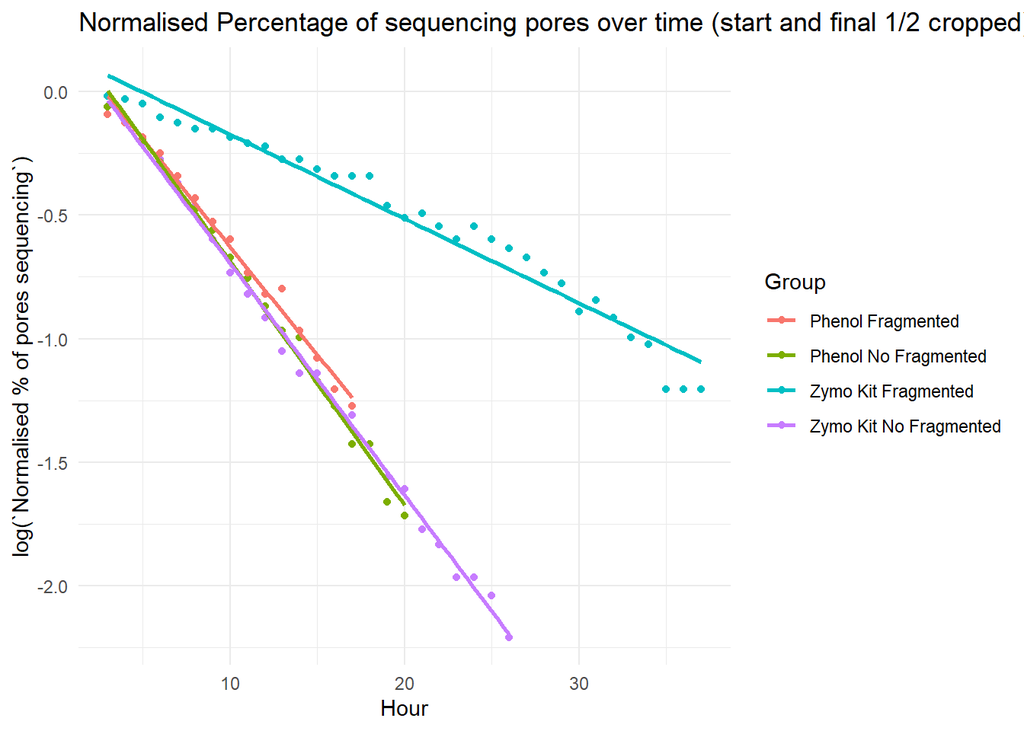

```r
# Plot overlaid linear model
ggplot(data=half_cropped_occupancy, aes(x=Hour, y=log(`Normalised % of pores sequencing`),color=Group))+ geom_point() + labs(title= "Normalised Percentage of sequencing pores over time (start and final 1/2 cropped)") + geom_smooth(method = "lm", formula = y ~ x, se = FALSE) + theme_minimal()
```

- **Phenol Fragmented:** = `-0.087147`
- **Phenol No Fragmented:**  
  `-0.011505 + -0.087147` = -0.098652
- **Zymo Kit Fragmented:**  
  `0.053055 + -0.087147` = -0.034092
- **Zymo Kit No Fragmented:**  
  `-0.006785 + -0.087147` = -0.093932

## Phenol No Fragmented vs. Zymo Kit No Fagmented. RESULT = Zymo No Fragmented is only marginally better (sig = * = 0.0457)

```r
lm_comparison1 <- lm(log(`Normalised % of pores sequencing`) ~ Hour * Group,
                              data = half_cropped_occupancy[half_cropped_occupancy$Group == 'Zymo Kit No Fragmented' |
                                                 half_cropped_occupancy$Group == 'Phenol No Fragmented',])
summary(lm_comparison1)
```

```
##
## Call:
## lm(formula = log(`Normalised % of pores sequencing`) ~ Hour *
##     Group, data = half_cropped_occupancy[half_cropped_occupancy$Group ==
##     "Zymo Kit No Fragmented" | half_cropped_occupancy$Group ==
##     "Phenol No Fragmented", ])
##
## Residuals:
##       Min        1Q    Median        3Q       Max
## -0.085664 -0.033277  0.007713  0.025763  0.087558
##
## Coefficients:
##                                   Estimate Std. Error t value Pr(>|t|)
## (Intercept)                       0.299309   0.024175  12.381 6.58e-15 ***
## Hour                             -0.098651   0.001916 -51.483  < 2e-16 ***
## GroupZymo Kit No Fragmented      -0.053518   0.031365  -1.706   0.0961 .
## Hour:GroupZymo Kit No Fragmented  0.004720   0.002284   2.066   0.0457 *
## ---
## Signif. codes:  0 '***' 0.001 '**' 0.01 '*' 0.05 '.' 0.1 ' ' 1
##
## Residual standard error: 0.04218 on 38 degrees of freedom
## Multiple R-squared:  0.9957, Adjusted R-squared:  0.9954
## F-statistic:  2937 on 3 and 38 DF,  p-value: < 2.2e-16
```

## Phenol No Fragmented vs Phenol Fragmented. RESULT = Phenol Fragmented better (sig = **)

```r
lm_comparison2 <- lm(log(`Normalised % of pores sequencing`) ~ Hour * Group,
                              data = half_cropped_occupancy[half_cropped_occupancy$Group == 'Phenol Fragmented' |
                                                 half_cropped_occupancy$Group == 'Phenol No Fragmented',])
summary(lm_comparison2)
```

```
##
## Call:
## lm(formula = log(`Normalised % of pores sequencing`) ~ Hour *
##     Group, data = half_cropped_occupancy[half_cropped_occupancy$Group ==
##     "Phenol Fragmented" | half_cropped_occupancy$Group == "Phenol No Fragmented",
##     ])
##
## Residuals:
##       Min        1Q    Median        3Q       Max
## -0.085664 -0.021883  0.006768  0.023755  0.091764
##
## Coefficients:
##                                 Estimate Std. Error t value Pr(>|t|)
## (Intercept)                     0.242637   0.027678   8.766  1.2e-09 ***
## Hour                           -0.087147   0.002541 -34.298  < 2e-16 ***
## GroupPhenol No Fragmented       0.056673   0.036877   1.537  0.13518
## Hour:GroupPhenol No Fragmented -0.011505   0.003192  -3.605  0.00116 **
## ---
## Signif. codes:  0 '***' 0.001 '**' 0.01 '*' 0.05 '.' 0.1 ' ' 1
##
## Residual standard error: 0.04252 on 29 degrees of freedom
## Multiple R-squared:  0.9928, Adjusted R-squared:  0.992
## F-statistic:  1326 on 3 and 29 DF,  p-value: < 2.2e-16
```

Check new cropped dataset to see if simple linear model is appropriate.

## 1. Check linearity. Check that the relationship between the

predictors (Hour, Group) and the log-transformed response variable (Normalised % of pores sequencing) is linear.

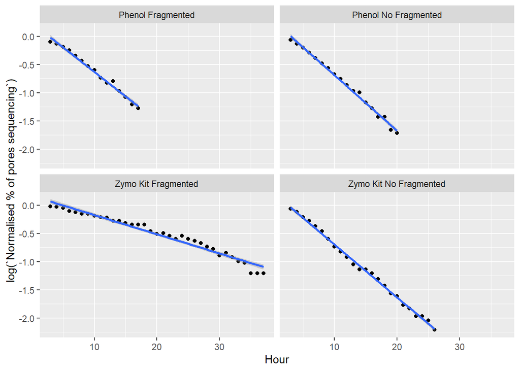

```r
library(ggplot2)
ggplot(half_cropped_occupancy, aes(x=Hour, y=log(`Normalised % of pores sequencing`))) +
  geom_point() +
  geom_smooth(method="lm") +
  facet_wrap(~Group)  # Adding facet_wrap to see plots by Group
```

Interpretation: In each condition, the relationship between time (Hour) and Percentage of pores sequencing is linear.

[output not shown]

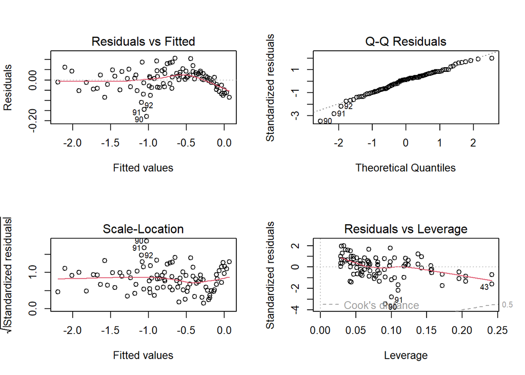

```r
model <- lm(log(`Normalised % of pores sequencing`) ~ Hour * Group, data = half_cropped_occupancy)
par(mfrow=c(2,2))
plot(model)
```

Interpretation: -**Residuals vs Fitted** This plot checks the assumption of linearity and homoscedasticity (constant variance of residuals).

Interpretation: Points following closely along the straight diagonal line indicate normality. Your Q-Q plot shows the residuals closely following the line in the middle quantiles, but with some slight deviation at the ends. This may suggest minor deviations from normality, such as light tails or outliers.

-**Scale-Location (or Spread-Location Plot)** This plot shows how residuals spread along the range of predictors. It is used to check the homoscedasticity assumption.

Interpretation: A horizontal line with equally spread points is ideal. Your plot shows points that are spread randomly without a pattern and the line appears fairly level, which indicates that the variance of the residuals is relatively constant, satisfying the assumption of homoscedasticity.

-**Residuals vs Leverage** This plot helps to identify influential observations that might have an undue influence on the regression line.

Interpretation: Observations with high leverage can potentially be influential points if they also have large residuals. In your plot, while there are some points with higher leverage, they do not appear to have large residuals. There are no points outside the Cook’s distance lines (which would typically be dashed lines indicating a measure of influence), which suggests there are no highly influential outliers that are unduly affecting the model.

Summary of Interpretation Overall, the diagnostic plots suggest that the assumptions of the linear model are reasonably well met. There is no clear pattern in the residuals, implying linearity and homoscedasticity. The Q-Q plot shows some minor deviations from normality, which may or may not be significant depending on the size of your dataset; larger datasets can tolerate slight deviations from normality. There do not appear to be any unduly influential data points according to the Residuals vs Leverage plot.

[output not shown]

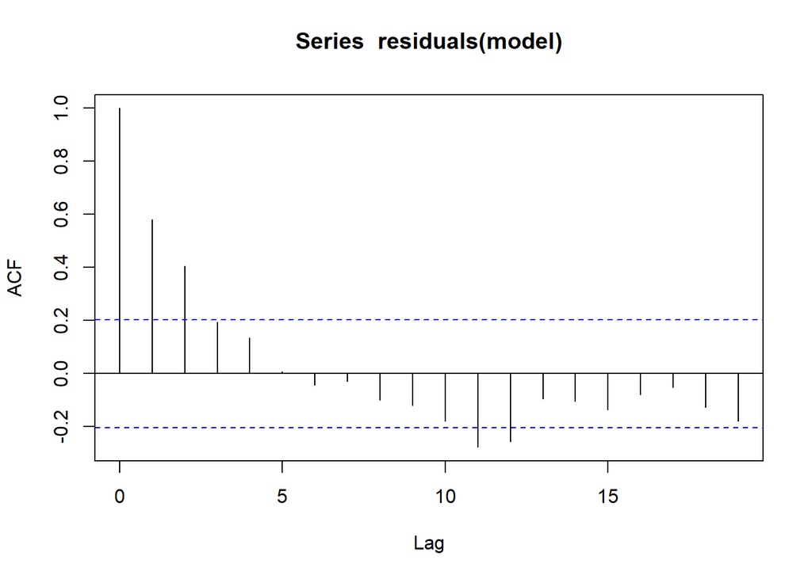

```r
acf(residuals(model))
```

# Plot the pore count data (number of active pores)

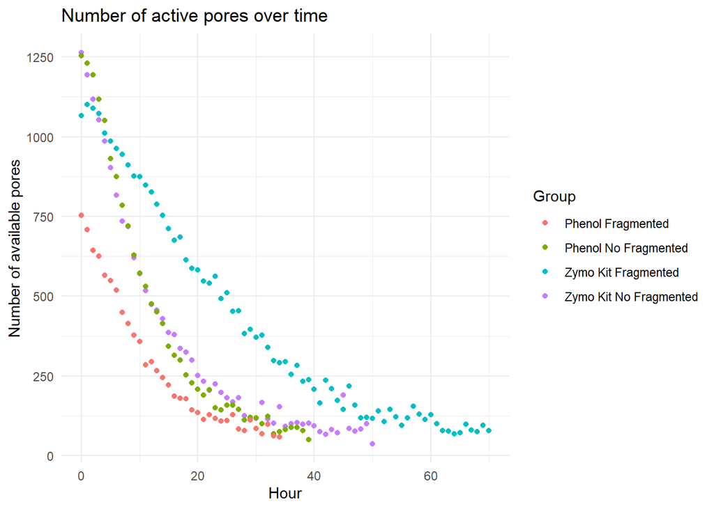

```r
# Plot the raw data
ggplot(data=porecount, aes(x=Hour, y=`Number of available pores`, color=Group))+ geom_point() + labs(title= "Number of active pores over time") + theme_minimal()
```

The data was log transformed to linearise it.

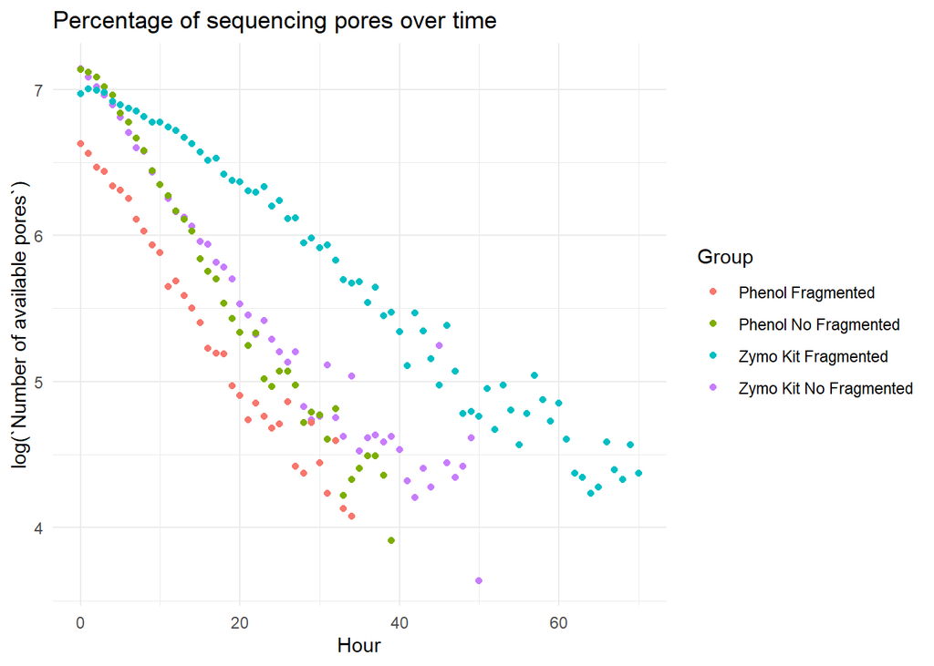

```r
# plot the data using a log transformation on the y axis to make the data linear
ggplot(data=porecount, aes(x=Hour, y=log(`Number of available pores`),color=Group))+ geom_point() + labs(title= "Percentage of sequencing pores over time") + theme_minimal()
```

Prepare data to crop the first 1 hour (where percentage of pores sequencing slowly rises) and the final part of the run, where percentage of pores sequencing is variable and non-informative as it tails off towards zero.

```r
# Calculate the maximum hour for each group
max_hours <- porecount %>%
  group_by(Group) %>%
  summarise(MaxHour = max(Hour))
# Merge the maximum hours with the original data
porecount <- porecount %>%
  left_join(max_hours, by = "Group")
```

```r
#crop the first 1 hour off each condition
front_cropped_count <- porecount %>%
  subset(Hour >= 2)
```